# Read Counts

The below make some sense: RAB7B is a GTPase that plays a role in the transport and degradation of proteins in endosomes and lysosomes in mammalian cells. CD52 is associated with the metabolism of proteins pathway and post-transcriptional modification. However, it seems to play a major role in T-cell/immunological function.

However, I haven’t been able to find any relation with the below: WNT4 promotes female sex development and repressess male development. Perhaps this is skewed/bias by the samples I chose? AKIRIN1 is involved in skeletal muscle development. PDZK1IP1 is a protein coding gene associated with spinal muscular atrophy and supreglottis neoplasm. GPR88 is a brain orphan G protein couple receptor, and aids in the striatum development (brain section for motor and reward systems).

ARPC5 is shown in some literature to have a larger affect. And it seems consistent with this study. ARPC5 encodes one of the subunits of the human Arp2/3 protein complex, which plays a large role in the regulation of the actin cytoskeleton.

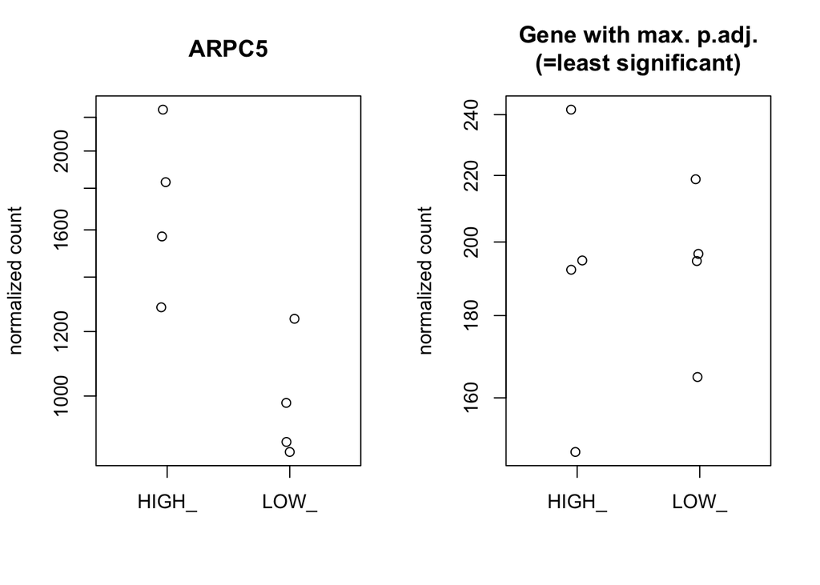

```r
par(mfrow=c(1,2))
plotCounts(DESeq.ds, gene="ARPC5", normalized = TRUE, xlab="")
plotCounts(DESeq.ds, gene = which.max(DGE.results$padj), xlab="",
           main = "Gene with max. p.adj.\n(=least significant)")
```

Unfortunately, by plotting the MA, you can see that there aren’t really many strongly differentiated genes.

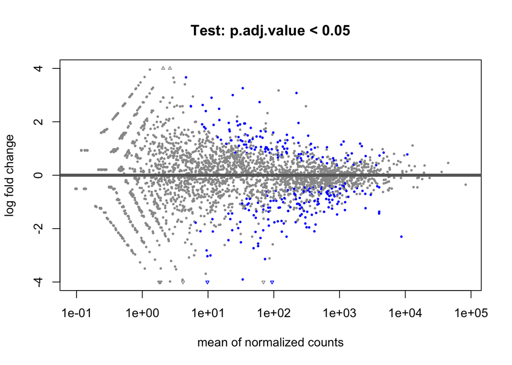

```r
plotMA(DGE.results, alpha=0.05,
      main="Test: p.adj.value < 0.05", ylim = c(-4,4))
```

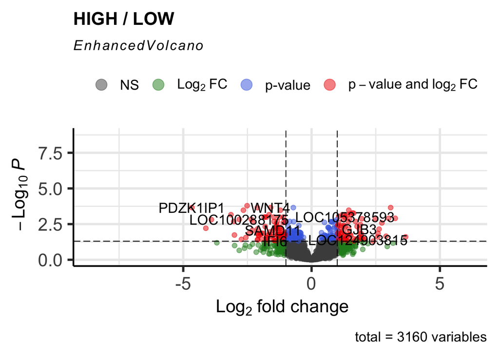

```r
#BiocManager::install("EnhancedVolcano")
library(EnhancedVolcano)
vp1 <- EnhancedVolcano(DGE.results,
                       lab=rownames(DGE.results),
                      x='log2FoldChange', y='padj',
                      pCutoff=0.05,
                      title="HIGH / LOW")
print(vp1)
```

Perhaps I need to set the baseline to the LOW condition and the experimental to the HIGH condition?

```r
pca_data <- plotPCA(rlog(DESeq.ds), intgroup="condition", returnData=TRUE)
```